# weather_power_prediction

Importing all the important Libraries.

```python
import pandas as pd
import numpy as np
import seaborn as sns
import matplotlib.pyplot as plt
from sklearn import preprocessing
from sklearn.preprocessing import StandardScaler
from sklearn.decomposition import PCA
from sklearn.preprocessing import Normalizer
from sklearn.linear_model import LinearRegression
from google.colab import files
from scipy import stats

print('importing done !')
```

```
importing done !
```

Reading all the required Files to be explored and process

```python
p_actual = pd.read_csv('/content/drive/My Drive/Python/Weather/power_actual.csv')
p_actual
```

|  | Unnamed: 0 | datetime | ghi | gti | power |
| --- | --- | --- | --- | --- | --- |
| 0 | 0 | 2017-10-01 00:00:00 | 0.0 | 0.0 | 0.0 |
| 1 | 1 | 2017-10-01 00:15:00 | 0.0 | 0.0 | 0.0 |
| 2 | 2 | 2017-10-01 00:30:00 | 0.0 | 0.0 | 0.0 |
| 3 | 3 | 2017-10-01 00:45:00 | 0.0 | 0.0 | 0.0 |
| 4 | 4 | 2017-10-01 01:00:00 | 0.0 | 0.0 | 0.0 |
| ... | ... | ... | ... | ... | ... |
| 70075 | 70075 | 2019-09-30 22:45:00 | 0.0 | 0.0 | 0.0 |
| 70076 | 70076 | 2019-09-30 23:00:00 | 0.0 | 0.0 | 0.0 |
| 70077 | 70077 | 2019-09-30 23:15:00 | 0.0 | 0.0 | 0.0 |
| 70078 | 70078 | 2019-09-30 23:30:00 | 0.0 | 0.0 | 0.0 |
| 70079 | 70079 | 2019-09-30 23:45:00 | 0.0 | 0.0 | 0.0 |

70080 rows × 5 columns

```python
p_actual.rename(columns={"datetime": "datetime_utc"}, inplace=True)
```

```python
p_actual
```

|  | Unnamed: 0 | datetime_utc | ghi | gti | power |
| --- | --- | --- | --- | --- | --- |
| 0 | 0 | 2017-10-01 00:00:00 | 0.0 | 0.0 | 0.0 |
| 1 | 1 | 2017-10-01 00:15:00 | 0.0 | 0.0 | 0.0 |
| 2 | 2 | 2017-10-01 00:30:00 | 0.0 | 0.0 | 0.0 |
| 3 | 3 | 2017-10-01 00:45:00 | 0.0 | 0.0 | 0.0 |
| 4 | 4 | 2017-10-01 01:00:00 | 0.0 | 0.0 | 0.0 |
| ... | ... | ... | ... | ... | ... |
| 70075 | 70075 | 2019-09-30 22:45:00 | 0.0 | 0.0 | 0.0 |
| 70076 | 70076 | 2019-09-30 23:00:00 | 0.0 | 0.0 | 0.0 |
| 70077 | 70077 | 2019-09-30 23:15:00 | 0.0 | 0.0 | 0.0 |
| 70078 | 70078 | 2019-09-30 23:30:00 | 0.0 | 0.0 | 0.0 |
| 70079 | 70079 | 2019-09-30 23:45:00 | 0.0 | 0.0 | 0.0 |

70080 rows × 5 columns

```python
p_actual.power.sum()
```

```
2005193.0671417748
```

```python
p_actual.power.isnull()
```

```
0        False
1        False
2        False
3        False
4        False
         ...
70075    False
70076    False
70077    False
70078    False
70079    False
Name: power, Length: 70080, dtype: bool
```

```python
w_actual=pd.read_csv('/content/drive/My Drive/Python/Weather/weather_actuals.csv')
w_actual
```

|  | Unnamed: 0 | plant_id | datetime_utc | datetime_local | cloud_cover | apparent_temperature | temperature | humidity | dew_point | wind_bearing | wind_speed | wind_chill | wind_gust | heat_index | pressure | qpf | uv_index | snow | pop | fctcode | ozone | precip_accumulation | precip_intensity | precip_probability | precip_type | visibility | sunrise | sunset | icon | … |
| --- | --- | --- | --- | --- | --- | --- | --- | --- | --- | --- | --- | --- | --- | --- | --- | --- | --- | --- | --- | --- | --- | --- | --- | --- | --- | --- | --- | --- | --- | --- |
| 0 | 0 | 1 | 2017-09-30 18:30:00 | 2017-10-01 00:00:00 | 0.00 | 26.52 | 26 | 1 | 19.46 | 308 | 0.83 | -9999.0 | -9999.00 | -9999.0 | 1007.90 | -9999.0 | -9999 | -9999.0 | -9999.0 | -9999.0 | -9999.0 | -9999.0 | -9999.0 | -9999.0 | rain | 3.57 | 2017-10-01 00:52:02 | 2017-10-01 12:45:07 | clear-night | … |
| 1 | 1 | 1 | 2017-09-30 19:30:00 | 2017-10-01 01:00:00 | 0.00 | 28.78 | 27 | 1 | 20.06 | -9999 | -9999.00 | -9999.0 | -9999.00 | -9999.0 | -9999.00 | -9999.0 | -9999 | -9999.0 | -9999.0 | -9999.0 | -9999.0 | -9999.0 | -9999.0 | -9999.0 | rain | 3.06 | 2017-10-01 00:52:02 | 2017-10-01 12:45:07 | fog | … |
| 2 | 2 | 1 | 2017-09-30 20:30:00 | 2017-10-01 02:00:00 | 0.00 | 26.58 | 26 | 1 | 19.97 | -9999 | -9999.00 | -9999.0 | -9999.00 | -9999.0 | -9999.00 | -9999.0 | -9999 | -9999.0 | -9999.0 | -9999.0 | -9999.0 | -9999.0 | -9999.0 | -9999.0 | rain | 3.06 | 2017-10-01 00:52:02 | 2017-10-01 12:45:07 | fog | … |
| 3 | 3 | 1 | 2017-09-30 21:30:00 | 2017-10-01 03:00:00 | 0.00 | 23.84 | 23 | 1 | 18.66 | 270 | 0.45 | -9999.0 | -9999.00 | -9999.0 | 1008.12 | -9999.0 | -9999 | -9999.0 | -9999.0 | -9999.0 | -9999.0 | -9999.0 | -9999.0 | -9999.0 | rain | 3.56 | 2017-10-01 00:52:02 | 2017-10-01 12:45:07 | clear-night | … |
| 4 | 4 | 1 | 2017-09-30 22:30:00 | 2017-10-01 04:00:00 | 0.00 | 24.13 | 24 | 1 | 17.84 | -9999 | -9999.00 | -9999.0 | -9999.00 | -9999.0 | -9999.00 | -9999.0 | -9999 | -9999.0 | -9999.0 | -9999.0 | -9999.0 | -9999.0 | -9999.0 | -9999.0 | rain | 3.06 | 2017-10-01 00:52:02 | 2017-10-01 12:45:07 | fog | … |
| ... | ... | ... | ... | ... | ... | ... | ... | ... | ... | ... | ... | ... | ... | ... | ... | ... | ... | ... | ... | ... | ... | ... | ... | ... | ... | ... | ... | ... | ... | … |
| 13614 | 13614 | 1 | 2019-09-30 13:30:00 | 2019-09-30 19:00:00 | 0.16 | 31.66 | 29 | 1 | 21.19 | 40 | 2.72 | NaN | 4.59 | NaN | 1007.44 | NaN | 0 | NaN | NaN | NaN | 269.6 | NaN | 0.0 | 0.0 | NaN | 16.09 | 2019-09-30 00:51:16 | 2019-09-30 12:46:54 | partly-cloudy-night | … |
| 13615 | 13615 | 1 | 2019-09-30 14:30:00 | 2019-09-30 20:00:00 | 0.16 | 30.42 | 28 | 1 | 21.35 | 59 | 3.24 | NaN | 5.45 | NaN | 1008.25 | NaN | 0 | NaN | NaN | NaN | 268.7 | NaN | 0.0 | 0.0 | NaN | 16.09 | 2019-09-30 00:51:16 | 2019-09-30 12:46:54 | partly-cloudy-night | … |
| 13616 | 13616 | 1 | 2019-09-30 15:30:00 | 2019-09-30 21:00:00 | 0.18 | 29.56 | 27 | 1 | 21.61 | 76 | 3.34 | NaN | 5.83 | NaN | 1008.65 | NaN | 0 | NaN | NaN | NaN | 268.4 | NaN | 0.0 | 0.0 | NaN | 16.09 | 2019-09-30 00:51:16 | 2019-09-30 12:46:54 | partly-cloudy-night | … |
| 13617 | 13617 | 1 | 2019-09-30 16:30:00 | 2019-09-30 22:00:00 | 0.30 | 28.97 | 27 | 1 | 21.99 | 88 | 3.22 | NaN | 5.73 | NaN | 1008.76 | NaN | 0 | NaN | NaN | NaN | 268.7 | NaN | 0.0 | 0.0 | NaN | 16.09 | 2019-09-30 00:51:16 | 2019-09-30 12:46:54 | partly-cloudy-night | … |
| 13618 | 13618 | 1 | 2019-09-30 17:30:00 | 2019-09-30 23:00:00 | 0.35 | 28.15 | 26 | 1 | 22.09 | 95 | 3.14 | NaN | 6.03 | NaN | 1008.61 | NaN | 0 | NaN | NaN | NaN | 268.7 | NaN | 0.0 | 0.0 | NaN | 16.09 | 2019-09-30 00:51:16 | 2019-09-30 12:46:54 | partly-cloudy-night | … |

13619 rows × 31 columns

```python
res = pd.merge(w_actual, p_actual, how='left', on=['datetime_utc'])
```

```python
res.replace([0,'0'],np.nan)
print(res.power.isnull().sum())
print(res.power.sum())
print(res.gti.sum())
```

```
6
507520.2200000001
0.0
```

```python
w_forecast=pd.read_csv('/content/drive/My Drive/Python/Weather/weather_forecast.csv')
w_forecast
```

|  | Unnamed: 0 | plant_id | datetime_utc | datetime_local | cloud_cover | apparent_temperature | temperature | humidity | dew_point | wind_bearing | wind_speed | wind_chill | wind_gust | heat_index | pressure | qpf | uv_index | snow | pop | fctcode | ozone | precip_accumulation | precip_intensity | precip_probability | precip_type | visibility | sunrise | sunset | icon | … |
| --- | --- | --- | --- | --- | --- | --- | --- | --- | --- | --- | --- | --- | --- | --- | --- | --- | --- | --- | --- | --- | --- | --- | --- | --- | --- | --- | --- | --- | --- | --- |
| 0 | 0 | 1 | 2019-09-30 18:30:00 | 2019-10-01 00:00:00 | 0.35 | 26.41 | 26 | 1 | 22.01 | 101 | 3.08 | NaN | 6.42 | NaN | 1008.45 | NaN | 0 | NaN | NaN | NaN | 268.6 | NaN | 0.0 | 0.0 | NaN | 16.09 | 2019-10-01 00:51:47 | 2019-10-01 12:45:42 | partly-cloudy-night | … |
| 1 | 1 | 1 | 2019-09-30 19:30:00 | 2019-10-01 01:00:00 | 0.43 | 25.95 | 25 | 1 | 22.06 | 105 | 2.94 | NaN | 6.28 | NaN | 1008.24 | NaN | 0 | NaN | NaN | NaN | 269.1 | NaN | 0.0 | 0.0 | NaN | 16.09 | 2019-10-01 00:51:47 | 2019-10-01 12:45:42 | partly-cloudy-night | … |
| 2 | 2 | 1 | 2019-09-30 20:30:00 | 2019-10-01 02:00:00 | 0.48 | 25.46 | 25 | 1 | 22.06 | 106 | 2.82 | NaN | 6.08 | NaN | 1007.90 | NaN | 0 | NaN | NaN | NaN | 269.7 | NaN | 0.0 | 0.0 | NaN | 16.09 | 2019-10-01 00:51:47 | 2019-10-01 12:45:42 | partly-cloudy-night | … |
| 3 | 3 | 1 | 2019-09-30 21:30:00 | 2019-10-01 03:00:00 | 0.49 | 24.80 | 24 | 1 | 21.87 | 106 | 2.63 | NaN | 5.74 | NaN | 1007.61 | NaN | 0 | NaN | NaN | NaN | 270.4 | NaN | 0.0 | 0.0 | NaN | 16.09 | 2019-10-01 00:51:47 | 2019-10-01 12:45:42 | partly-cloudy-night | … |
| 4 | 4 | 1 | 2019-09-30 22:30:00 | 2019-10-01 04:00:00 | 0.49 | 23.99 | 23 | 1 | 21.53 | 100 | 2.39 | NaN | 5.30 | NaN | 1007.51 | NaN | 0 | NaN | NaN | NaN | 271.3 | NaN | 0.0 | 0.0 | NaN | 16.09 | 2019-10-01 00:51:47 | 2019-10-01 12:45:42 | partly-cloudy-night | … |
| ... | ... | ... | ... | ... | ... | ... | ... | ... | ... | ... | ... | ... | ... | ... | ... | ... | ... | ... | ... | ... | ... | ... | ... | ... | ... | ... | ... | ... | ... | … |
| 643 | 643 | 1 | 2019-10-27 13:30:00 | 2019-10-27 19:00:00 | 0.00 | 27.23 | 27 | 0 | 12.20 | 345 | 1.74 | NaN | 2.85 | NaN | 1011.70 | NaN | 0 | NaN | NaN | NaN | 264.9 | NaN | 0.0 | 0.0 | NaN | 16.09 | 2019-10-27 01:07:31 | 2019-10-27 12:18:06 | clear-night | … |
| 644 | 644 | 1 | 2019-10-27 14:30:00 | 2019-10-27 20:00:00 | 0.00 | 25.23 | 25 | 0 | 12.06 | 353 | 1.39 | NaN | 2.73 | NaN | 1012.28 | NaN | 0 | NaN | NaN | NaN | 264.9 | NaN | 0.0 | 0.0 | NaN | 16.09 | 2019-10-27 01:07:31 | 2019-10-27 12:18:06 | clear-night | … |
| 645 | 645 | 1 | 2019-10-27 15:30:00 | 2019-10-27 21:00:00 | 0.00 | 23.75 | 24 | 0 | 12.19 | 29 | 1.15 | NaN | 2.55 | NaN | 1012.67 | NaN | 0 | NaN | NaN | NaN | 264.6 | NaN | 0.0 | 0.0 | NaN | 16.09 | 2019-10-27 01:07:31 | 2019-10-27 12:18:06 | clear-night | … |
| 646 | 646 | 1 | 2019-10-27 16:30:00 | 2019-10-27 22:00:00 | 0.00 | 22.86 | 23 | 1 | 12.50 | 92 | 1.03 | NaN | 2.33 | NaN | 1012.79 | NaN | 0 | NaN | NaN | NaN | 264.3 | NaN | 0.0 | 0.0 | NaN | 16.09 | 2019-10-27 01:07:31 | 2019-10-27 12:18:06 | clear-night | … |
| 647 | 647 | 1 | 2019-10-27 17:30:00 | 2019-10-27 23:00:00 | 0.00 | 22.21 | 22 | 1 | 12.67 | 146 | 0.91 | NaN | 2.01 | NaN | 1012.85 | NaN | 0 | NaN | NaN | NaN | 262.8 | NaN | 0.0 | 0.0 | NaN | 16.09 | 2019-10-27 01:07:31 | 2019-10-27 12:18:06 | clear-night | … |

648 rows × 31 columns

```python
w_train=res.copy()
```

Printing the Info of the training Data set. By just seeing the data set we can easily see that there are many null values and -9999 values imputed. I will consider it as wrong and trying to drop them

```python
print(w_train.info())
```

```
<class 'pandas.core.frame.DataFrame'>
Int64Index: 13619 entries, 0 to 13618
Data columns (total 35 columns):
 #   Column                Non-Null Count  Dtype
---  ------                --------------  -----
 0   Unnamed: 0_x          13619 non-null  int64
 1   plant_id              13619 non-null  int64
 2   datetime_utc          13619 non-null  object
 3   datetime_local        13619 non-null  object
 4   cloud_cover           13619 non-null  float64
 5   apparent_temperature  13619 non-null  float64
 6   temperature           13619 non-null  int64
 7   humidity              13619 non-null  int64
 8   dew_point             13619 non-null  float64
 9   wind_bearing          13619 non-null  int64
```

[output cut: 28 more lines]

```python
w_train
```

|  | Unnamed: 0_x | plant_id | datetime_utc | datetime_local | cloud_cover | apparent_temperature | temperature | humidity | dew_point | wind_bearing | wind_speed | wind_chill | wind_gust | heat_index | pressure | qpf | uv_index | snow | pop | fctcode | ozone | precip_accumulation | precip_intensity | precip_probability | precip_type | visibility | sunrise | sunset | icon | … |
| --- | --- | --- | --- | --- | --- | --- | --- | --- | --- | --- | --- | --- | --- | --- | --- | --- | --- | --- | --- | --- | --- | --- | --- | --- | --- | --- | --- | --- | --- | --- |
| 0 | 0 | 1 | 2017-09-30 18:30:00 | 2017-10-01 00:00:00 | 0.00 | 26.52 | 26 | 1 | 19.46 | 308 | 0.83 | -9999.0 | -9999.00 | -9999.0 | 1007.90 | -9999.0 | -9999 | -9999.0 | -9999.0 | -9999.0 | -9999.0 | -9999.0 | -9999.0 | -9999.0 | rain | 3.57 | 2017-10-01 00:52:02 | 2017-10-01 12:45:07 | clear-night | … |
| 1 | 1 | 1 | 2017-09-30 19:30:00 | 2017-10-01 01:00:00 | 0.00 | 28.78 | 27 | 1 | 20.06 | -9999 | -9999.00 | -9999.0 | -9999.00 | -9999.0 | -9999.00 | -9999.0 | -9999 | -9999.0 | -9999.0 | -9999.0 | -9999.0 | -9999.0 | -9999.0 | -9999.0 | rain | 3.06 | 2017-10-01 00:52:02 | 2017-10-01 12:45:07 | fog | … |
| 2 | 2 | 1 | 2017-09-30 20:30:00 | 2017-10-01 02:00:00 | 0.00 | 26.58 | 26 | 1 | 19.97 | -9999 | -9999.00 | -9999.0 | -9999.00 | -9999.0 | -9999.00 | -9999.0 | -9999 | -9999.0 | -9999.0 | -9999.0 | -9999.0 | -9999.0 | -9999.0 | -9999.0 | rain | 3.06 | 2017-10-01 00:52:02 | 2017-10-01 12:45:07 | fog | … |
| 3 | 3 | 1 | 2017-09-30 21:30:00 | 2017-10-01 03:00:00 | 0.00 | 23.84 | 23 | 1 | 18.66 | 270 | 0.45 | -9999.0 | -9999.00 | -9999.0 | 1008.12 | -9999.0 | -9999 | -9999.0 | -9999.0 | -9999.0 | -9999.0 | -9999.0 | -9999.0 | -9999.0 | rain | 3.56 | 2017-10-01 00:52:02 | 2017-10-01 12:45:07 | clear-night | … |
| 4 | 4 | 1 | 2017-09-30 22:30:00 | 2017-10-01 04:00:00 | 0.00 | 24.13 | 24 | 1 | 17.84 | -9999 | -9999.00 | -9999.0 | -9999.00 | -9999.0 | -9999.00 | -9999.0 | -9999 | -9999.0 | -9999.0 | -9999.0 | -9999.0 | -9999.0 | -9999.0 | -9999.0 | rain | 3.06 | 2017-10-01 00:52:02 | 2017-10-01 12:45:07 | fog | … |
| ... | ... | ... | ... | ... | ... | ... | ... | ... | ... | ... | ... | ... | ... | ... | ... | ... | ... | ... | ... | ... | ... | ... | ... | ... | ... | ... | ... | ... | ... | … |
| 13614 | 13614 | 1 | 2019-09-30 13:30:00 | 2019-09-30 19:00:00 | 0.16 | 31.66 | 29 | 1 | 21.19 | 40 | 2.72 | NaN | 4.59 | NaN | 1007.44 | NaN | 0 | NaN | NaN | NaN | 269.6 | NaN | 0.0 | 0.0 | NaN | 16.09 | 2019-09-30 00:51:16 | 2019-09-30 12:46:54 | partly-cloudy-night | … |
| 13615 | 13615 | 1 | 2019-09-30 14:30:00 | 2019-09-30 20:00:00 | 0.16 | 30.42 | 28 | 1 | 21.35 | 59 | 3.24 | NaN | 5.45 | NaN | 1008.25 | NaN | 0 | NaN | NaN | NaN | 268.7 | NaN | 0.0 | 0.0 | NaN | 16.09 | 2019-09-30 00:51:16 | 2019-09-30 12:46:54 | partly-cloudy-night | … |
| 13616 | 13616 | 1 | 2019-09-30 15:30:00 | 2019-09-30 21:00:00 | 0.18 | 29.56 | 27 | 1 | 21.61 | 76 | 3.34 | NaN | 5.83 | NaN | 1008.65 | NaN | 0 | NaN | NaN | NaN | 268.4 | NaN | 0.0 | 0.0 | NaN | 16.09 | 2019-09-30 00:51:16 | 2019-09-30 12:46:54 | partly-cloudy-night | … |
| 13617 | 13617 | 1 | 2019-09-30 16:30:00 | 2019-09-30 22:00:00 | 0.30 | 28.97 | 27 | 1 | 21.99 | 88 | 3.22 | NaN | 5.73 | NaN | 1008.76 | NaN | 0 | NaN | NaN | NaN | 268.7 | NaN | 0.0 | 0.0 | NaN | 16.09 | 2019-09-30 00:51:16 | 2019-09-30 12:46:54 | partly-cloudy-night | … |
| 13618 | 13618 | 1 | 2019-09-30 17:30:00 | 2019-09-30 23:00:00 | 0.35 | 28.15 | 26 | 1 | 22.09 | 95 | 3.14 | NaN | 6.03 | NaN | 1008.61 | NaN | 0 | NaN | NaN | NaN | 268.7 | NaN | 0.0 | 0.0 | NaN | 16.09 | 2019-09-30 00:51:16 | 2019-09-30 12:46:54 | partly-cloudy-night | … |

13619 rows × 35 columns

```python
#Dropping some columns that does not contribute to the output
w_train1=w_train.drop(['Unnamed: 0_x','plant_id','datetime_local','temperature','Unnamed: 0_y','updated_at','ghi','gti'],axis=1, inplace=False)
```

```python
w_train1
```

|  | datetime_utc | cloud_cover | apparent_temperature | humidity | dew_point | wind_bearing | wind_speed | wind_chill | wind_gust | heat_index | pressure | qpf | uv_index | snow | pop | fctcode | ozone | precip_accumulation | precip_intensity | precip_probability | precip_type | visibility | sunrise | sunset | icon | summary | power |
| --- | --- | --- | --- | --- | --- | --- | --- | --- | --- | --- | --- | --- | --- | --- | --- | --- | --- | --- | --- | --- | --- | --- | --- | --- | --- | --- | --- |
| 0 | 2017-09-30 18:30:00 | 0.00 | 26.52 | 1 | 19.46 | 308 | 0.83 | -9999.0 | -9999.00 | -9999.0 | 1007.90 | -9999.0 | -9999 | -9999.0 | -9999.0 | -9999.0 | -9999.0 | -9999.0 | -9999.0 | -9999.0 | rain | 3.57 | 2017-10-01 00:52:02 | 2017-10-01 12:45:07 | clear-night | Clear | NaN |
| 1 | 2017-09-30 19:30:00 | 0.00 | 28.78 | 1 | 20.06 | -9999 | -9999.00 | -9999.0 | -9999.00 | -9999.0 | -9999.00 | -9999.0 | -9999 | -9999.0 | -9999.0 | -9999.0 | -9999.0 | -9999.0 | -9999.0 | -9999.0 | rain | 3.06 | 2017-10-01 00:52:02 | 2017-10-01 12:45:07 | fog | Foggy | NaN |
| 2 | 2017-09-30 20:30:00 | 0.00 | 26.58 | 1 | 19.97 | -9999 | -9999.00 | -9999.0 | -9999.00 | -9999.0 | -9999.00 | -9999.0 | -9999 | -9999.0 | -9999.0 | -9999.0 | -9999.0 | -9999.0 | -9999.0 | -9999.0 | rain | 3.06 | 2017-10-01 00:52:02 | 2017-10-01 12:45:07 | fog | Foggy | NaN |
| 3 | 2017-09-30 21:30:00 | 0.00 | 23.84 | 1 | 18.66 | 270 | 0.45 | -9999.0 | -9999.00 | -9999.0 | 1008.12 | -9999.0 | -9999 | -9999.0 | -9999.0 | -9999.0 | -9999.0 | -9999.0 | -9999.0 | -9999.0 | rain | 3.56 | 2017-10-01 00:52:02 | 2017-10-01 12:45:07 | clear-night | Clear | NaN |
| 4 | 2017-09-30 22:30:00 | 0.00 | 24.13 | 1 | 17.84 | -9999 | -9999.00 | -9999.0 | -9999.00 | -9999.0 | -9999.00 | -9999.0 | -9999 | -9999.0 | -9999.0 | -9999.0 | -9999.0 | -9999.0 | -9999.0 | -9999.0 | rain | 3.06 | 2017-10-01 00:52:02 | 2017-10-01 12:45:07 | fog | Foggy | NaN |
| ... | ... | ... | ... | ... | ... | ... | ... | ... | ... | ... | ... | ... | ... | ... | ... | ... | ... | ... | ... | ... | ... | ... | ... | ... | ... | ... | ... |
| 13614 | 2019-09-30 13:30:00 | 0.16 | 31.66 | 1 | 21.19 | 40 | 2.72 | NaN | 4.59 | NaN | 1007.44 | NaN | 0 | NaN | NaN | NaN | 269.6 | NaN | 0.0 | 0.0 | NaN | 16.09 | 2019-09-30 00:51:16 | 2019-09-30 12:46:54 | partly-cloudy-night | Partly Cloudy | 0.0 |
| 13615 | 2019-09-30 14:30:00 | 0.16 | 30.42 | 1 | 21.35 | 59 | 3.24 | NaN | 5.45 | NaN | 1008.25 | NaN | 0 | NaN | NaN | NaN | 268.7 | NaN | 0.0 | 0.0 | NaN | 16.09 | 2019-09-30 00:51:16 | 2019-09-30 12:46:54 | partly-cloudy-night | Partly Cloudy | 0.0 |
| 13616 | 2019-09-30 15:30:00 | 0.18 | 29.56 | 1 | 21.61 | 76 | 3.34 | NaN | 5.83 | NaN | 1008.65 | NaN | 0 | NaN | NaN | NaN | 268.4 | NaN | 0.0 | 0.0 | NaN | 16.09 | 2019-09-30 00:51:16 | 2019-09-30 12:46:54 | partly-cloudy-night | Partly Cloudy | 0.0 |
| 13617 | 2019-09-30 16:30:00 | 0.30 | 28.97 | 1 | 21.99 | 88 | 3.22 | NaN | 5.73 | NaN | 1008.76 | NaN | 0 | NaN | NaN | NaN | 268.7 | NaN | 0.0 | 0.0 | NaN | 16.09 | 2019-09-30 00:51:16 | 2019-09-30 12:46:54 | partly-cloudy-night | Partly Cloudy | 0.0 |
| 13618 | 2019-09-30 17:30:00 | 0.35 | 28.15 | 1 | 22.09 | 95 | 3.14 | NaN | 6.03 | NaN | 1008.61 | NaN | 0 | NaN | NaN | NaN | 268.7 | NaN | 0.0 | 0.0 | NaN | 16.09 | 2019-09-30 00:51:16 | 2019-09-30 12:46:54 | partly-cloudy-night | Partly Cloudy | 0.0 |

13619 rows × 27 columns

From here I have done preprocessing on every column, if a column has too many nan values or -9999 values the column is dropped. Otherwise the rows are dropped else the column is not being touched.

Only those columns will be visible on which the preprocessing is done.

```python
w_train1.drop(w_train1[w_train1['cloud_cover'] == -9999.00 ].index, inplace = True)
w_train1.cloud_cover.value_counts()
```

```
0.00    6528
1.00     556
0.01     371
0.03     206
0.02     188
        ...
0.77      34
0.52      32
0.58      31
0.73      29
0.47      27
Name: cloud_cover, Length: 101, dtype: int64
```

```python
w_train1.drop(w_train1[w_train1['dew_point'] == -9999.00 ].index, inplace = True)
w_train1.dew_point.dropna(inplace=True)
w_train1.shape
```

```
(13191, 27)
```

```python
w_train1.drop(w_train1[w_train1['wind_bearing'] == -9999.00 ].index, inplace = True)
w_train1.wind_bearing.dropna(inplace=True)
w_train1.shape
```

```
(12345, 27)
```

```python
w_train1.drop(w_train1[w_train1['wind_speed'] == -9999.00 ].index, inplace = True)
w_train1.wind_speed.dropna(inplace=True)
w_train1.shape
```

```
(12345, 27)
```

```python
w_train1.drop(['wind_speed'], axis=1, inplace=True)
w_train1.shape
```

```
(12345, 26)
```

```python
w_train1.drop(['wind_chill'], axis=1, inplace=True)
w_train1.shape
```

```
(12345, 25)
```

```python
w_train1.drop(w_train1[w_train1['wind_gust'] == -9999.00 ].index, inplace = True)
w_train1.shape
```

```
(10355, 25)
```

```python
w_train1.drop(['heat_index'], axis=1, inplace=True)
w_train1.shape
```

```
(10355, 24)
```

```python
w_train1.drop(['qpf'], axis=1, inplace=True)
w_train1.shape
```

```
(10355, 23)
```

```python
w_train1.drop(['snow'], axis=1, inplace=True)
w_train1.shape
```

```
(10355, 22)
```

```python
w_train1.drop(['pop'], axis=1, inplace=True)
```

```python
w_train1.drop(['fctcode'], axis=1, inplace=True)
```

```python
w_train1.drop(['precip_accumulation'], axis=1, inplace=True)
w_train1.shape
```

```
(10355, 19)
```

```python
w_train1.drop(['precip_type'], axis=1, inplace=True)
w_train1.shape
```

```
(10355, 18)
```

```python
w_train1.drop(w_train1[w_train1['visibility'] == -9999.00 ].index, inplace = True)
w_train1.visibility.value_counts()
w_train1.shape
```

```
(10179, 18)
```

```python
w_train1.drop(['sunrise', 'sunset'], axis=1, inplace=True)
w_train1.shape
```

```
(10179, 16)
```

```python
#icon column has some discrete text values so I will label Encode them.
w_train1.icon.value_counts()
```

```
clear-night            2833
clear-day              2616
partly-cloudy-day      1720
partly-cloudy-night    1428
cloudy                 1297
fog                     191
rain                     94
Name: icon, dtype: int64
```

```python
w_train1.drop(['summary'], axis=1, inplace=True)
w_train1.shape
```

```
(10179, 15)
```

```python
#Label Encoding the icon column
label_encoder = preprocessing.LabelEncoder()
w_train1['icon']= label_encoder.fit_transform(w_train1['icon'])
```

```python
#reseting the index
w_train1.reset_index(inplace = True)
```

```python
w_train1.drop(['index'], axis=1, inplace=True)
w_train1.shape
```

```
(10179, 15)
```

```python
w_train1
```

|  | datetime_utc | cloud_cover | apparent_temperature | humidity | dew_point | wind_bearing | wind_gust | pressure | uv_index | ozone | precip_intensity | precip_probability | visibility | icon | power |
| --- | --- | --- | --- | --- | --- | --- | --- | --- | --- | --- | --- | --- | --- | --- | --- |
| 0 | 2018-02-13 18:30:00 | 0.11 | 13.83 | 1 | 8.19 | 335 | 3.26 | 1024.00 | 0 | 335.82 | 0.0 | 0.00 | 1.88 | 3 | 0.0 |
| 1 | 2018-02-13 19:30:00 | 0.00 | 13.63 | 1 | 8.82 | 307 | 3.27 | 1023.93 | 0 | 333.09 | 0.0 | 0.00 | 2.57 | 3 | 0.0 |
| 2 | 2018-02-13 20:30:00 | 0.00 | 13.60 | 1 | 9.07 | 318 | 3.32 | 1023.86 | 0 | 330.29 | 0.0 | 0.01 | 2.57 | 3 | 0.0 |
| 3 | 2018-02-13 21:30:00 | 0.09 | 11.66 | 1 | 9.24 | 322 | 3.33 | 1024.28 | 0 | 328.21 | 0.0 | 0.01 | 1.90 | 3 | 0.0 |
| 4 | 2018-02-13 22:30:00 | 0.00 | 12.55 | 1 | 9.31 | 297 | 3.29 | 1023.72 | 0 | 326.80 | 0.0 | 0.01 | 2.57 | 3 | 0.0 |
| ... | ... | ... | ... | ... | ... | ... | ... | ... | ... | ... | ... | ... | ... | ... | ... |
| 10174 | 2019-09-30 13:30:00 | 0.16 | 31.66 | 1 | 21.19 | 40 | 4.59 | 1007.44 | 0 | 269.60 | 0.0 | 0.00 | 16.09 | 5 | 0.0 |
| 10175 | 2019-09-30 14:30:00 | 0.16 | 30.42 | 1 | 21.35 | 59 | 5.45 | 1008.25 | 0 | 268.70 | 0.0 | 0.00 | 16.09 | 5 | 0.0 |
| 10176 | 2019-09-30 15:30:00 | 0.18 | 29.56 | 1 | 21.61 | 76 | 5.83 | 1008.65 | 0 | 268.40 | 0.0 | 0.00 | 16.09 | 5 | 0.0 |
| 10177 | 2019-09-30 16:30:00 | 0.30 | 28.97 | 1 | 21.99 | 88 | 5.73 | 1008.76 | 0 | 268.70 | 0.0 | 0.00 | 16.09 | 5 | 0.0 |
| 10178 | 2019-09-30 17:30:00 | 0.35 | 28.15 | 1 | 22.09 | 95 | 6.03 | 1008.61 | 0 | 268.70 | 0.0 | 0.00 | 16.09 | 5 | 0.0 |

10179 rows × 15 columns

Here We can see there are too many out liers in the training dataset so we have to remove them with the help of Z-score and interquartile range.

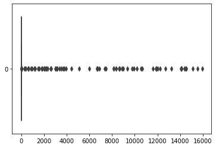

```python
sns.boxplot(data=w_train1['power'],orient="h")
```

```python
#here we will create the new data frame for doing preprocessing for z-score and interquartile ranges
w_train2=w_train1.drop(['datetime_utc'], axis=1, inplace=False)
#we will check with the z-score
z = np.abs(stats.zscore(w_train2))
print(z)
```

```
[[0.50124518 1.40862909 1.02295723 ... 5.57798992 0.52944147 0.07191329]
 [0.80363373 1.42810882 1.02295723 ... 5.29705732 0.52944147 0.07191329]
 [0.80363373 1.43103078 1.02295723 ... 5.29705732 0.52944147 0.07191329]
 ...
 [0.30881609 0.12345213 1.02295723 ... 0.20759304 1.61236816 0.07191329]
 [0.02106233 0.06598691 1.02295723 ... 0.20759304 1.61236816 0.07191329]
 [0.15851168 0.01388001 1.02295723 ... 0.20759304 1.61236816 0.07191329]]
```

```python
threshold = 2.5
print(np.where(z > 2.5))
```

```
(array([   0,    0,    1, ..., 9983, 9984, 9985]), array([ 8, 11,  8, ...,  9,  9,  9]))
```

```python
#here we will check interquartile ranges.
Q1 = w_train2.quantile(0.25)
Q3 = w_train2.quantile(0.75)
IQR = Q3 - Q1
print(IQR)
```

```
cloud_cover               0.590
apparent_temperature     16.725
humidity                  1.000
dew_point                17.605
wind_bearing            211.000
wind_gust                 2.670
pressure                 13.785
uv_index                  3.000
ozone                    16.000
precip_intensity          0.010
precip_probability        0.010
visibility                0.000
icon                      4.000
power                     6.100
dtype: float64
```

```python
print(w_train2 < (Q1 - 1.5 * IQR)) and (w_train2 > (Q3 + 1.5 * IQR))
```

```
       cloud_cover  apparent_temperature  humidity  ...  visibility   icon  power
0            False                 False     False  ...        True  False  False
1            False                 False     False  ...        True  False  False
2            False                 False     False  ...        True  False  False
3            False                 False     False  ...        True  False  False
4            False                 False     False  ...        True  False  False
...            ...                   ...       ...  ...         ...    ...    ...
10174        False                 False     False  ...       False  False  False
10175        False                 False     False  ...       False  False  False
10176        False                 False     False  ...       False  False  False
10177        False                 False     False  ...       False  False  False
10178        False                 False     False  ...       False  False  False

[10179 rows x 14 columns]
```

Here we will create a new dataset again for z-score and compare it with the interquartile ranges

```python
#Making a new dataframe with z-score conditions
w_train3 = w_train2[(z < 2.5).all(axis=1)]
w_train3.reset_index(inplace = True)
print(w_train3.shape)
```

```
(8606, 15)
```

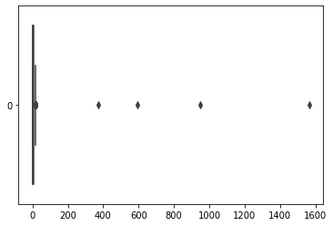

```python
#box plotting the target variable
sns.boxplot(data=w_train3['power'],orient='h')
```

```python
#Making a new dataframe with interquartile conditions
w_train4 = w_train2[~((w_train2 < (Q1 - 1.5 * IQR)) |(w_train2 > (Q3 + 1.5 * IQR))).any(axis=1)]
w_train4.shape
```

```
(6146, 14)
```

```python
w_train4.reset_index(inplace = True)
```

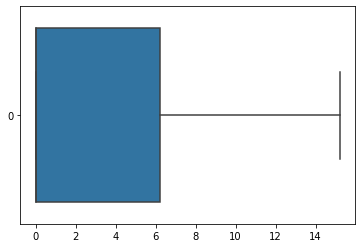

```python
#box plotting the target variable
sns.boxplot(data=w_train4['power'],orient='h')
```

As we can clearly the interquartile range gives a better plot so we will consider the interquartile way of removing outliers

We can afford to loose rows from training data as the testing data is very small in comparision to training data.

we will drop all the columns from testing dataset which we have dropped from training dataset.

```python
#dropping all the undesirable columns.
w_forecast.drop(['Unnamed: 0','plant_id','datetime_local','temperature','updated_at','wind_speed','wind_chill','heat_index','qpf','snow', 'pop', 'fctcode','precip_accumulation','precip_type','sunrise', 'sunset','summary'],axis=1, inplace=True)
w_forecast
```

|  | datetime_utc | cloud_cover | apparent_temperature | humidity | dew_point | wind_bearing | wind_gust | pressure | uv_index | ozone | precip_intensity | precip_probability | visibility | icon |
| --- | --- | --- | --- | --- | --- | --- | --- | --- | --- | --- | --- | --- | --- | --- |
| 0 | 2019-09-30 18:30:00 | 0.35 | 26.41 | 1 | 22.01 | 101 | 6.42 | 1008.45 | 0 | 268.6 | 0.0 | 0.0 | 16.09 | partly-cloudy-night |
| 1 | 2019-09-30 19:30:00 | 0.43 | 25.95 | 1 | 22.06 | 105 | 6.28 | 1008.24 | 0 | 269.1 | 0.0 | 0.0 | 16.09 | partly-cloudy-night |
| 2 | 2019-09-30 20:30:00 | 0.48 | 25.46 | 1 | 22.06 | 106 | 6.08 | 1007.90 | 0 | 269.7 | 0.0 | 0.0 | 16.09 | partly-cloudy-night |
| 3 | 2019-09-30 21:30:00 | 0.49 | 24.80 | 1 | 21.87 | 106 | 5.74 | 1007.61 | 0 | 270.4 | 0.0 | 0.0 | 16.09 | partly-cloudy-night |
| 4 | 2019-09-30 22:30:00 | 0.49 | 23.99 | 1 | 21.53 | 100 | 5.30 | 1007.51 | 0 | 271.3 | 0.0 | 0.0 | 16.09 | partly-cloudy-night |
| ... | ... | ... | ... | ... | ... | ... | ... | ... | ... | ... | ... | ... | ... | ... |
| 643 | 2019-10-27 13:30:00 | 0.00 | 27.23 | 0 | 12.20 | 345 | 2.85 | 1011.70 | 0 | 264.9 | 0.0 | 0.0 | 16.09 | clear-night |
| 644 | 2019-10-27 14:30:00 | 0.00 | 25.23 | 0 | 12.06 | 353 | 2.73 | 1012.28 | 0 | 264.9 | 0.0 | 0.0 | 16.09 | clear-night |
| 645 | 2019-10-27 15:30:00 | 0.00 | 23.75 | 0 | 12.19 | 29 | 2.55 | 1012.67 | 0 | 264.6 | 0.0 | 0.0 | 16.09 | clear-night |
| 646 | 2019-10-27 16:30:00 | 0.00 | 22.86 | 1 | 12.50 | 92 | 2.33 | 1012.79 | 0 | 264.3 | 0.0 | 0.0 | 16.09 | clear-night |
| 647 | 2019-10-27 17:30:00 | 0.00 | 22.21 | 1 | 12.67 | 146 | 2.01 | 1012.85 | 0 | 262.8 | 0.0 | 0.0 | 16.09 | clear-night |

648 rows × 14 columns

```python
#label encoding the icon column
label_encoder1 = preprocessing.LabelEncoder()
w_forecast['icon']= label_encoder1.fit_transform(w_forecast['icon'])
```

```python
w_forecast.isnull().sum()
```

```
datetime_utc            0
cloud_cover             0
apparent_temperature    0
humidity                0
dew_point               0
wind_bearing            0
wind_gust               0
pressure                0
uv_index                0
ozone                   0
precip_intensity        0
precip_probability      0
visibility              0
icon                    0
dtype: int64
```

Differentiating numerical and categorical columns for better column wise description

```python
for col in w_train4.columns:
  if w_train4[col].dtype == int:
    w_train4[col] = w_train4[col].astype(float)

numerical_columns= [cols for cols in w_train4.columns if w_train4[cols].dtype == float]
categorical_columns = [cols for cols in w_train4.columns if w_train4[cols].dtype == object]
w_train4.info()
```

```
<class 'pandas.core.frame.DataFrame'>
RangeIndex: 6146 entries, 0 to 6145
Data columns (total 15 columns):
 #   Column                Non-Null Count  Dtype
---  ------                --------------  -----
 0   index                 6146 non-null   float64
 1   cloud_cover           6146 non-null   float64
 2   apparent_temperature  6146 non-null   float64
 3   humidity              6146 non-null   float64
 4   dew_point             6146 non-null   float64
 5   wind_bearing          6146 non-null   float64
 6   wind_gust             6146 non-null   float64
 7   pressure              6146 non-null   float64
 8   uv_index              6146 non-null   float64
 9   ozone                 6146 non-null   float64
 10  precip_intensity      6146 non-null   float64
 11  precip_probability    6146 non-null   float64
 12  visibility            6146 non-null   float64
 13  icon                  6146 non-null   float64
 14  power                 6146 non-null   float64
dtypes: float64(15)
memory usage: 720.4 KB
```

```python
for col in w_forecast.columns:
  if w_forecast[col].dtype == int:
    w_forecast[col] = w_forecast[col].astype(float)

numerical_columns1= [cols for cols in w_forecast.columns if w_forecast[cols].dtype == float]
categorical_columns1 = [cols for cols in w_forecast.columns if w_forecast[cols].dtype == object]
w_forecast.info()
```

```
<class 'pandas.core.frame.DataFrame'>
RangeIndex: 648 entries, 0 to 647
Data columns (total 14 columns):
 #   Column                Non-Null Count  Dtype
---  ------                --------------  -----
 0   datetime_utc          648 non-null    object
 1   cloud_cover           648 non-null    float64
 2   apparent_temperature  648 non-null    float64
 3   humidity              648 non-null    float64
 4   dew_point             648 non-null    float64
 5   wind_bearing          648 non-null    float64
 6   wind_gust             648 non-null    float64
 7   pressure              648 non-null    float64
 8   uv_index              648 non-null    float64
 9   ozone                 648 non-null    float64
 10  precip_intensity      648 non-null    float64
 11  precip_probability    648 non-null    float64
 12  visibility            648 non-null    float64
 13  icon                  648 non-null    float64
dtypes: float64(13), object(1)
memory usage: 71.0+ KB
```

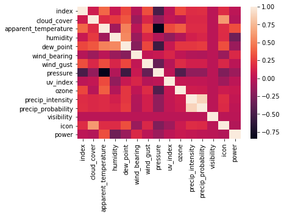

```python
#checking the correlation between the features.
corr = w_train4.corr()
sns.heatmap(corr)
```

```python
w_train4[numerical_columns].describe()
```

|  | index | cloud_cover | apparent_temperature | humidity | dew_point | wind_bearing | wind_gust | pressure | uv_index | ozone | precip_intensity | precip_probability | visibility | icon | power |
| --- | --- | --- | --- | --- | --- | --- | --- | --- | --- | --- | --- | --- | --- | --- | --- |
| count | 6146.000000 | 6146.000000 | 6146.000000 | 6146.000000 | 6146.000000 | 6146.000000 | 6146.000000 | 6146.000000 | 6146.000000 | 6146.000000 | 6146.000000 | 6146.000000 | 6.146000e+03 | 6146.000000 | 6146.000000 |
| mean | 4866.615848 | 0.221608 | 26.814707 | 0.418809 | 10.353049 | 175.328506 | 3.866656 | 1009.600838 | 1.234950 | 273.491913 | 0.000989 | 0.000993 | 1.609000e+01 | 1.782297 | 3.221365 |
| std | 2692.064555 | 0.330444 | 9.746658 | 0.493404 | 9.524354 | 116.189762 | 1.767116 | 7.507919 | 2.056751 | 12.530815 | 0.003675 | 0.003687 | 2.288134e-12 | 1.791069 | 4.973351 |
| min | 331.000000 | 0.000000 | 4.310000 | 0.000000 | -20.560000 | 0.000000 | 0.640000 | 991.840000 | 0.000000 | 243.700000 | 0.000000 | 0.000000 | 1.609000e+01 | 0.000000 | 0.000000 |
| 25% | 2436.250000 | 0.000000 | 19.120000 | 0.000000 | 3.845000 | 79.000000 | 2.570000 | 1003.360000 | 0.000000 | 266.100000 | 0.000000 | 0.000000 | 1.609000e+01 | 0.000000 | 0.000000 |
| 50% | 4614.500000 | 0.010000 | 27.335000 | 0.000000 | 9.130000 | 136.000000 | 3.470000 | 1010.060000 | 0.000000 | 274.300000 | 0.000000 | 0.000000 | 1.609000e+01 | 1.000000 | 0.000000 |
| 75% | 6936.750000 | 0.380000 | 34.310000 | 1.000000 | 18.097500 | 302.000000 | 4.877500 | 1015.707500 | 2.000000 | 281.900000 | 0.000000 | 0.000000 | 1.609000e+01 | 4.000000 | 6.197500 |
| max | 10178.000000 | 1.000000 | 48.550000 | 1.000000 | 28.350000 | 359.000000 | 9.360000 | 1025.690000 | 7.000000 | 307.100000 | 0.020000 | 0.020000 | 1.609000e+01 | 5.000000 | 15.220000 |

```python
w_forecast[numerical_columns1].describe()
```

|  | cloud_cover | apparent_temperature | humidity | dew_point | wind_bearing | wind_gust | pressure | uv_index | ozone | precip_intensity | precip_probability | visibility | icon |
| --- | --- | --- | --- | --- | --- | --- | --- | --- | --- | --- | --- | --- | --- |
| count | 648.000000 | 648.000000 | 648.000000 | 648.000000 | 648.000000 | 648.000000 | 648.000000 | 648.000000 | 648.000000 | 648.000000 | 648.000000 | 6.480000e+02 | 648.000000 |
| mean | 0.140340 | 27.562423 | 0.513889 | 14.789244 | 144.282407 | 3.462068 | 1011.430108 | 1.591049 | 275.790432 | 0.007608 | 0.002423 | 1.609000e+01 | 1.192901 |
| std | 0.273487 | 4.596587 | 0.500193 | 3.616508 | 116.665398 | 1.533301 | 1.957697 | 2.451580 | 3.228630 | 0.032064 | 0.006543 | 1.102192e-13 | 1.281715 |
| min | 0.000000 | 18.300000 | 0.000000 | 2.950000 | 0.000000 | 0.840000 | 1005.920000 | 0.000000 | 262.800000 | 0.000000 | 0.000000 | 1.609000e+01 | 0.000000 |
| 25% | 0.000000 | 23.817500 | 0.000000 | 12.620000 | 51.750000 | 2.370000 | 1010.127500 | 0.000000 | 274.300000 | 0.000000 | 0.000000 | 1.609000e+01 | 0.000000 |
| 50% | 0.000000 | 27.155000 | 1.000000 | 14.900000 | 109.000000 | 3.100000 | 1011.365000 | 0.000000 | 276.100000 | 0.000000 | 0.000000 | 1.609000e+01 | 1.000000 |
| 75% | 0.110000 | 31.942500 | 1.000000 | 17.182500 | 273.500000 | 4.050000 | 1012.640000 | 3.000000 | 277.600000 | 0.000000 | 0.000000 | 1.609000e+01 | 1.000000 |
| max | 1.000000 | 36.340000 | 1.000000 | 22.350000 | 359.000000 | 10.540000 | 1016.900000 | 8.000000 | 284.900000 | 0.420000 | 0.060000 | 1.609000e+01 | 4.000000 |

```python
w_forecast[categorical_columns1].describe()
```

|  | datetime_utc |
| --- | --- |
| count | 648 |
| unique | 648 |
| top | 2019-10-16 09:30:00 |
| freq | 1 |

```python
#making a copy of training and testing data
Xtrain=w_train4.copy()
Xtest=w_forecast.copy()
```

```python
#applying standard scaler to the training dataset
ytrain= Xtrain['power']
Xtrain.drop(['power','index'],axis=1, inplace=True)
print(Xtrain.shape)
print(ytrain.shape)
print(np.mean(Xtrain),np.std(Xtrain))
Xtrain = StandardScaler().fit_transform(Xtrain)
print(np.mean(Xtrain),np.std(Xtrain))
```

```
(6146, 13)
(6146,)
cloud_cover                0.221608
apparent_temperature      26.814707
humidity                   0.418809
dew_point                 10.353049
wind_bearing             175.328506
wind_gust                  3.866656
pressure                1009.600838
uv_index                   1.234950
ozone                    273.491913
precip_intensity           0.000989
precip_probability         0.000993
visibility                16.090000
icon                       1.782297
dtype: float64 cloud_cover             3.304167e-01
apparent_temperature    9.745865e+00
humidity                4.933640e-01
dew_point               9.523579e+00
wind_bearing            1.161803e+02
wind_gust               1.766972e+00
pressure                7.507308e+00
uv_index                2.056584e+00
ozone                   1.252980e+01
precip_intensity        3.674551e-03
precip_probability      3.686937e-03
visibility              2.287948e-12
icon                    1.790923e+00
dtype: float64
-0.07692307692307655 0.9970370305242862
```

```python
#applying standard scaler to the testing dataset
Xtest.drop(['datetime_utc'],axis=1, inplace=True)
Xtest = StandardScaler().fit_transform(Xtest)
print(np.mean(Xtest),np.std(Xtest))
```

```
9.936127050396463e-16 0.9607689228305228
```

```python
#applying normalizer to the training and testing dataset
scaler = Normalizer()
normalized_Xtrain = scaler.fit_transform(Xtrain)
normalized_Xtest = scaler.fit_transform(Xtest)
```

```python
print(np.mean(normalized_Xtrain),np.std(normalized_Xtrain))
print(np.mean(normalized_Xtest),np.std(normalized_Xtest))
```

```
-0.03900885291810975 0.2745931286778498
-0.015984703973643277 0.27688908639011384
```

Here We will apply Machine Learning Model to the dataset.

```python
#Applying Linear regression
lr = LinearRegression(normalize=True)
lr.fit(Xtrain,ytrain)
ypred=lr.predict(Xtest)
ypred[0:100]
```

```
array([-5.82737114, -6.66082263, -7.75103524, -8.90348231, -9.8819149 ,
       -8.95796262, -6.81217419, -5.57329038, -4.69539764, -1.80499924,
        0.36897627,  1.91898081,  1.83224931,  1.63476019,  0.97817449,
        0.37690914,  1.11299569,  0.86008386,  0.49974579,  0.65540146,
        0.6682102 ,  0.17946127, -1.18893016, -1.88198892, -2.59434854,
       -3.26480354, -3.74169459, -4.29227832, -5.01748366, -4.91118278,
       -3.42881264, -1.68549867, -0.09872697,  2.83225072,  3.00892863,
        2.13246401,  1.47244417,  1.07892588,  2.48479715,  3.28194836,
        4.06310328,  4.19651899,  4.67134746,  2.5378573 ,  0.99393296,
        0.02601699, -0.75477512, -1.57592507, -2.45540589, -4.24758482,
       -4.50970821, -5.00726775, -5.41232464, -4.68164529, -3.55523539,
       -2.06681479,  0.18789583,  2.61381984,  4.70677955,  7.38928748,
        5.51976742,  4.00554869,  6.56122839,  7.24817429,  6.67997814,
        5.88478495,  2.93985101,  1.39193458,  1.23778499,  0.65039451,
        0.73900623,  0.89040137,  0.08505075, -2.47791268, -4.03505104,
       -5.10262079, -5.40866518, -4.24661833, -2.02048472,  0.40880797,
        1.7842278 ,  4.01208318,  6.19691735,  5.35433773,  6.16315149,
        4.20609165,  2.79017995,  3.55444184,  4.48861393,  5.55855662,
        4.26510584,  2.02274148,  1.67606649,  1.1909736 ,  0.51981469,
       -1.17698609, -2.55034993, -4.36226722, -5.86700112, -6.67943124])
```

```python
#storing the predicted values in a dataframe
weather_power=pd.DataFrame(ypred)
```

```python
weather_power
```

|  | 0 |
| --- | --- |
| 0 | -5.827371 |
| 1 | -6.660823 |
| 2 | -7.751035 |
| 3 | -8.903482 |
| 4 | -9.881915 |
| ... | ... |
| 643 | 6.398141 |
| 644 | 5.053305 |
| 645 | 2.497405 |
| 646 | 1.062907 |
| 647 | 0.551301 |

648 rows × 1 columns

```python
weather_power_linear_reg=weather_power.to_csv('weather_power_linear_reg.csv')
files.download("weather_power_linear_reg.csv")
```

```python
Xtrain.shape
```

```
(6146, 13)
```

```python
#Applying PCA
pca = PCA(n_components=4)
pca_weather=pca.fit_transform(Xtrain)
```

```python
#converting the PCA components in dataframe
pca_weather_df_train=pd.DataFrame(data=pca_weather, columns = ['pc1', 'pc2','pc3','pc4'])
pca_weather_df_train
```

|  | pc1 | pc2 | pc3 | pc4 |
| --- | --- | --- | --- | --- |
| 0 | 4.782479 | 2.271971 | 3.350616 | 0.762409 |
| 1 | 2.330456 | 0.715559 | -1.847897 | 0.011418 |
| 2 | 2.468919 | 0.794471 | -1.938420 | 0.178527 |
| 3 | 4.822268 | 2.973293 | 2.792478 | -0.243313 |
| 4 | 2.952032 | 0.614266 | -2.103169 | 0.154815 |
| ... | ... | ... | ... | ... |
| 6141 | 1.452646 | 1.042640 | -1.627679 | -0.412409 |
| 6142 | 1.457538 | 1.063555 | -1.641330 | -0.433042 |
| 6143 | 1.464649 | 1.086924 | -1.648560 | -0.400953 |
| 6144 | 1.532918 | 1.199421 | -1.707571 | -0.190253 |
| 6145 | 1.592445 | 1.239494 | -1.751780 | -0.132747 |

6146 rows × 4 columns

```python
#Applying PCA to testing dataset
pca1 = PCA(n_components=4)
pca_weather1=pca1.fit_transform(Xtest)
```

```python
pca_weather_df_test=pd.DataFrame(data=pca_weather1, columns = ['pc1', 'pc2','pc3','pc4'])
pca_weather_df_test
```

|  | pc1 | pc2 | pc3 | pc4 |
| --- | --- | --- | --- | --- |
| 0 | 3.224739 | -0.037573 | -2.392562 | 0.930465 |
| 1 | 3.300988 | 0.074055 | -2.498232 | 0.872397 |
| 2 | 3.330590 | 0.147215 | -2.599916 | 0.721297 |
| 3 | 3.285159 | 0.145239 | -2.625051 | 0.512797 |
| 4 | 3.212468 | 0.101004 | -2.566760 | 0.267433 |
| ... | ... | ... | ... | ... |
| 643 | -0.874381 | -0.544691 | -0.449819 | 2.727411 |
| 644 | -0.767728 | -0.762195 | -0.191808 | 2.903232 |
| 645 | -0.197861 | -1.266555 | 0.119335 | 1.528647 |
| 646 | 0.705831 | -1.763700 | 0.582155 | 1.871414 |
| 647 | 0.702712 | -1.769804 | 0.609251 | 2.374612 |

648 rows × 4 columns

```python
#Applying Linear Regression to PCA dataframe
lr = LinearRegression(normalize=True)
lr.fit(pca_weather_df_train,ytrain)
ypred_pca=lr.predict(pca_weather_df_test)
ypred_pca[0:100]
```

```
array([ 2.82485608,  2.62450225,  2.40643147,  2.2664438 ,  2.19083552,
        2.23707229,  2.2270861 ,  2.47524053,  2.42307526,  1.95974406,
        1.51981583,  0.36059969, -0.10910295, -0.53044477, -1.7232104 ,
       -1.24787707, -1.02761225, -0.8162707 ,  0.35985712, -0.20760287,
        0.536631  ,  0.9896239 ,  2.04045255,  3.41890521,  3.90365913,
        3.81651572,  3.75278211,  3.73480763,  3.77511367,  3.79235139,
        3.07394833,  3.11465231,  2.99477603,  2.71497292,  2.442801  ,
        1.2158111 ,  0.92631517,  1.14645844,  0.06178725, -0.71625182,
        0.14428962,  0.3458691 ,  1.28793647,  2.1553444 ,  2.55839353,
        2.0426198 ,  2.37824614,  2.57414148,  2.34745183,  2.25316184,
        2.30773807,  2.25843264,  2.26745986,  2.22279144,  2.30752433,
        2.92074211,  1.674025  ,  2.27716248,  0.24506064, -5.38191951,
       -4.04383349, -0.37128607, -0.17708726, -1.04570691, -1.11306783,
       -1.38575018, -2.09363243,  1.03317322,  3.28597293,  3.64706959,
        4.06395327,  3.21130095,  3.18307881,  4.28149173,  4.18267964,
        4.12384294,  4.04702838,  3.12861695,  1.90464207,  0.76507015,
       -1.43869563, -1.88728232,  0.25477359,  0.5913587 ,  0.40405362,
        0.40792056,  0.53001554,  1.43122993,  1.41567669,  1.01790052,
        1.48708928,  2.42103118,  2.56153864,  3.28313017,  3.37533344,
        3.46409375,  3.32875718,  3.22584985,  3.19971738,  3.28212031])
```

```python
#storing the predicted values by using PCA in a new DataFrame.
weather_power_pca=pd.DataFrame(ypred_pca)
```

```python
weather_power_pca
```

|  | 0 |
| --- | --- |
| 0 | 2.824856 |
| 1 | 2.624502 |
| 2 | 2.406431 |
| 3 | 2.266444 |
| 4 | 2.190836 |
| ... | ... |
| 643 | 5.086922 |
| 644 | 5.566664 |
| 645 | 5.492446 |
| 646 | 6.547008 |
| 647 | 6.867470 |

648 rows × 1 columns

```python
weather_power_linear_reg_pca=weather_power_pca.to_csv('weather_power_linear_reg_pca.csv')
files.download("weather_power_linear_reg_pca.csv")
```

```python
#storing the predicted values by simple LR in weather_forecasting dataframe
w_forecast['power_linear']=ypred
```

```python
#storing the predicted values by PCA and LR in Weather_forecasting dataframe
w_forecast['power_linear_pca']=ypred_pca
```

```python
w_forecast
```

|  | datetime_utc | cloud_cover | apparent_temperature | humidity | dew_point | wind_bearing | wind_gust | pressure | uv_index | ozone | precip_intensity | precip_probability | visibility | icon | power_linear | power_linear_pca |
| --- | --- | --- | --- | --- | --- | --- | --- | --- | --- | --- | --- | --- | --- | --- | --- | --- |
| 0 | 2019-09-30 18:30:00 | 0.35 | 26.41 | 1.0 | 22.01 | 101.0 | 6.42 | 1008.45 | 0.0 | 268.6 | 0.0 | 0.0 | 16.09 | 4.0 | -5.827371 | 2.824856 |
| 1 | 2019-09-30 19:30:00 | 0.43 | 25.95 | 1.0 | 22.06 | 105.0 | 6.28 | 1008.24 | 0.0 | 269.1 | 0.0 | 0.0 | 16.09 | 4.0 | -6.660823 | 2.624502 |
| 2 | 2019-09-30 20:30:00 | 0.48 | 25.46 | 1.0 | 22.06 | 106.0 | 6.08 | 1007.90 | 0.0 | 269.7 | 0.0 | 0.0 | 16.09 | 4.0 | -7.751035 | 2.406431 |
| 3 | 2019-09-30 21:30:00 | 0.49 | 24.80 | 1.0 | 21.87 | 106.0 | 5.74 | 1007.61 | 0.0 | 270.4 | 0.0 | 0.0 | 16.09 | 4.0 | -8.903482 | 2.266444 |
| 4 | 2019-09-30 22:30:00 | 0.49 | 23.99 | 1.0 | 21.53 | 100.0 | 5.30 | 1007.51 | 0.0 | 271.3 | 0.0 | 0.0 | 16.09 | 4.0 | -9.881915 | 2.190836 |
| ... | ... | ... | ... | ... | ... | ... | ... | ... | ... | ... | ... | ... | ... | ... | ... | ... |
| 643 | 2019-10-27 13:30:00 | 0.00 | 27.23 | 0.0 | 12.20 | 345.0 | 2.85 | 1011.70 | 0.0 | 264.9 | 0.0 | 0.0 | 16.09 | 1.0 | 6.398141 | 5.086922 |
| 644 | 2019-10-27 14:30:00 | 0.00 | 25.23 | 0.0 | 12.06 | 353.0 | 2.73 | 1012.28 | 0.0 | 264.9 | 0.0 | 0.0 | 16.09 | 1.0 | 5.053305 | 5.566664 |
| 645 | 2019-10-27 15:30:00 | 0.00 | 23.75 | 0.0 | 12.19 | 29.0 | 2.55 | 1012.67 | 0.0 | 264.6 | 0.0 | 0.0 | 16.09 | 1.0 | 2.497405 | 5.492446 |
| 646 | 2019-10-27 16:30:00 | 0.00 | 22.86 | 1.0 | 12.50 | 92.0 | 2.33 | 1012.79 | 0.0 | 264.3 | 0.0 | 0.0 | 16.09 | 1.0 | 1.062907 | 6.547008 |
| 647 | 2019-10-27 17:30:00 | 0.00 | 22.21 | 1.0 | 12.67 | 146.0 | 2.01 | 1012.85 | 0.0 | 262.8 | 0.0 | 0.0 | 16.09 | 1.0 | 0.551301 | 6.867470 |

648 rows × 16 columns

Here We will do some visualizations of Data and compare both the PCA and non PCA models and we will plot features relations with the prediction columns as well

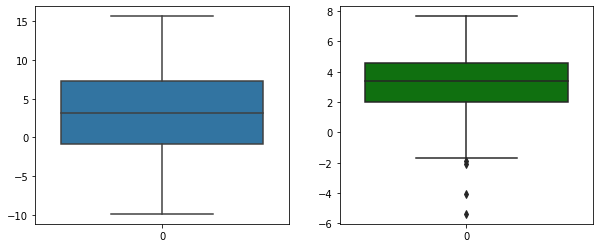

```python
fig, (axis1,axis2) = plt.subplots(1, 2, figsize=(10,4))
ax=sns.boxplot(ax=axis1, data=w_forecast.power_linear, orient='v')
ax=sns.boxplot(ax=axis2, data=w_forecast.power_linear_pca, orient='v', color='green')
```

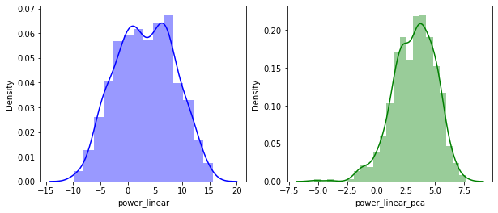

```python
fig, (axis1,axis2) = plt.subplots(1, 2, figsize=(10,4))
ax= sns.distplot(w_forecast.power_linear,kde=True, color='b', ax=axis1)
ax= sns.distplot(w_forecast.power_linear_pca,kde=True, ax=axis2, color='g')
```

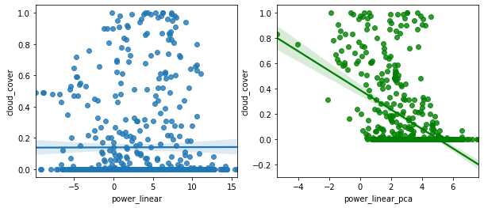

```python
fig, (axis1,axis2) = plt.subplots(1, 2, figsize=(10,4))
ax= sns.regplot(x='power_linear',y='cloud_cover',fit_reg=True,data=w_forecast,ax=axis1)
ax= sns.regplot(x='power_linear_pca',y='cloud_cover',fit_reg=True,data=w_forecast,ax=axis2,color='green')
```

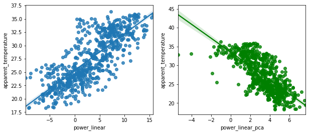

```python
fig, (axis1,axis2) = plt.subplots(1, 2, figsize=(10,4))
ax=sns.regplot(x='power_linear',y='apparent_temperature',fit_reg=True,data=w_forecast, ax=axis1)
ax=sns.regplot(x='power_linear_pca',y='apparent_temperature',fit_reg=True,data=w_forecast, ax=axis2,color='green')
```

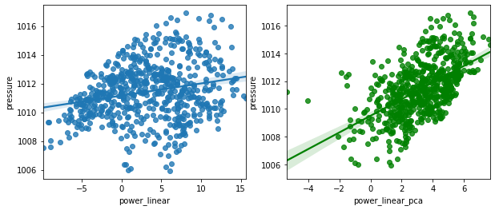

```python
fig, (axis1,axis2) = plt.subplots(1, 2, figsize=(10,4))
ax=sns.regplot(x='power_linear',y='pressure',fit_reg=True,data=w_forecast, ax=axis1)
ax=sns.regplot(x='power_linear_pca',y='pressure',fit_reg=True,data=w_forecast, ax=axis2,color='green')
```

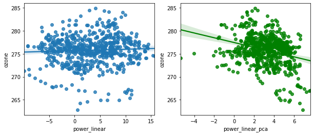

```python
fig, (axis1,axis2) = plt.subplots(1, 2, figsize=(10,4))
ax= sns.regplot(x='power_linear',y='ozone',fit_reg=True,data=w_forecast,ax=axis1)
ax= sns.regplot(x='power_linear_pca',y='ozone',fit_reg=True,data=w_forecast,ax=axis2,color='green')
```

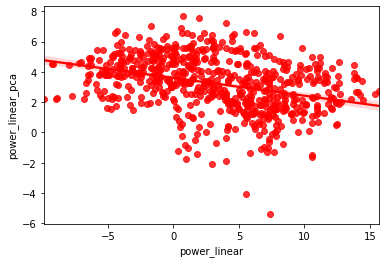

```python
#plotting simple linear model with PCA_Linear model
sns.regplot(x='power_linear',y='power_linear_pca',fit_reg=True,data=w_forecast, color='red')
```